# Polygenic Risk Score Analysis without Proteomics

```r
env_data_prs <- read.csv("../notebooks/merged_datasets/env_data_prs.csv")
```

## Run logistic regression model for pollution + phenotypes + PRS dataset

```r
model_env_prs <- glm(disease ~ age + sex + waist_circumference + body_fat_percent +
                     no2 + nox + pm25_2010 + PRS,
                     data = env_data_prs, family = binomial)
summary(model_env_prs)
```

```
Call:
glm(formula = disease ~ age + sex + waist_circumference + body_fat_percent +
    no2 + nox + pm25_2010 + PRS, family = binomial, data = env_data_prs)

Deviance Residuals:
    Min       1Q   Median       3Q      Max
-1.8400  -0.0581  -0.0323  -0.0177   4.7638

Coefficients:
                      Estimate Std. Error z value Pr(>|z|)
(Intercept)          6.948e+01  1.617e+00  42.975  < 2e-16 ***
age                  9.789e-02  4.878e-03  20.066  < 2e-16 ***
sex                  1.691e+00  1.618e-01  10.449  < 2e-16 ***
waist_circumference  2.485e-01  6.244e-02   3.980 6.88e-05 ***
body_fat_percent     4.610e-01  7.669e-02   6.011 1.85e-09 ***
no2                 -1.014e-01  1.160e-02  -8.737  < 2e-16 ***
nox                  2.313e-02  5.311e-03   4.355 1.33e-05 ***
pm25_2010            2.696e-01  5.638e-02   4.781 1.75e-06 ***
PRS                  1.049e+05  2.003e+03  52.395  < 2e-16 ***
---
Signif. codes:  0 ‘***’ 0.001 ‘**’ 0.01 ‘*’ 0.05 ‘.’ 0.1 ‘ ’ 1

(Dispersion parameter for binomial family taken to be 1)

    Null deviance: 14567  on 391397  degrees of freedom
Residual deviance: 10862  on 391389  degrees of freedom
AIC: 10880

Number of Fisher Scoring iterations: 10
```

It loks like adding PRS is improving my model performance from 13,800 to 10,880 and my risidual deviance decreased by ~3,000 points.

The phenotype covariates that were significant in my prior models are also significant here: age, sex, waist circumference, and body fat %.

All 3 pollution variables were significant this time (NO2, NOx, , and PM2.5) although I am seeixng a negative association with NO2 which I'm not sure makes sense to me.

### Forest Plot for pollution + phenotypes + PRS dataset

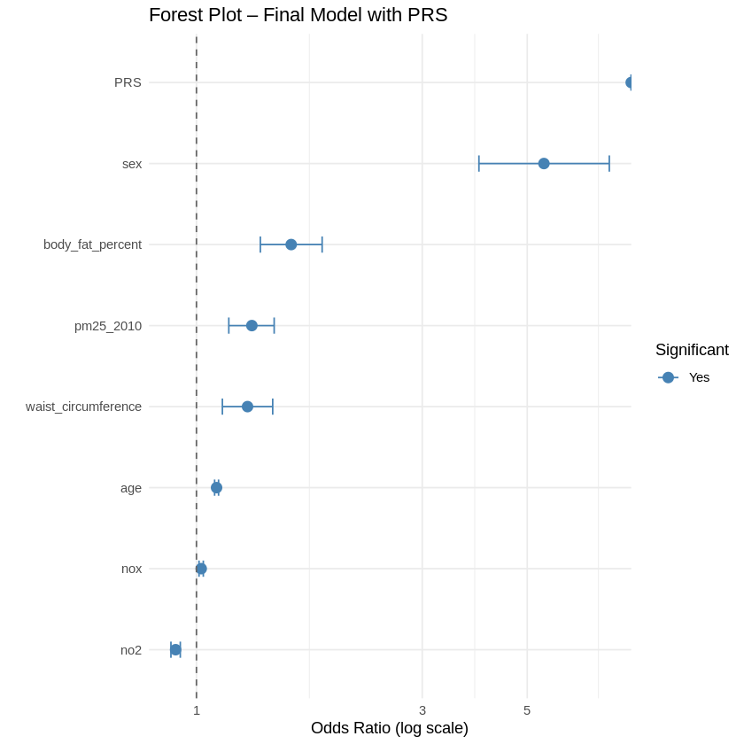

```r
# Model output
coef_env_prs <- summary(model_env_prs)$coefficients
conf_env_prs <- confint(model_env_prs)

# Create data frame
df_env_prs_plot <- data.frame(
  Variable = rownames(coef_env_prs),
  OR = exp(coef_env_prs[, "Estimate"]),
  LowerCI = exp(conf_env_prs[, 1]),
  UpperCI = exp(conf_env_prs[, 2]),
  p_value = coef_env_prs[, "Pr(>|z|)"]
)

# Clean and filter
df_env_prs_plot <- df_env_prs_plot[df_env_prs_plot$Variable != "(Intercept)", ]
df_env_prs_plot$Significant <- ifelse(df_env_prs_plot$p_value < 0.05, "Yes", "No")

# Plot
library(ggplot2)
ggplot(df_env_prs_plot, aes(x = reorder(Variable, OR), y = OR, color = Significant)) +
  geom_point(size = 3) +
  geom_errorbar(aes(ymin = LowerCI, ymax = UpperCI), width = 0.2) +
  geom_hline(yintercept = 1, linetype = "dashed", color = "gray40") +
  coord_flip() +
  scale_y_log10() +
  scale_color_manual(values = c("Yes" = "steelblue", "No" = "gray")) +
  labs(title = "Forest Plot – Final Model with PRS", y = "Odds Ratio (log scale)", x = "") +
  theme_minimal()
```

```r
library(knitr)
kable(df_env_prs_plot, digits = 3, caption = "Model Results – Phenotype + Pollution")
```

```
Table: Model Results – Phenotype + Pollution

|                    |Variable            |    OR| LowerCI| UpperCI| p_value|Significant |
|:-------------------|:-------------------|-----:|-------:|-------:|-------:|:-----------|
|age                 |age                 | 1.103|   1.092|   1.114|       0|Yes         |
|sex                 |sex                 | 5.423|   3.953|   7.453|       0|Yes         |
|waist_circumference |waist_circumference | 1.282|   1.135|   1.449|       0|Yes         |
|body_fat_percent    |body_fat_percent    | 1.586|   1.365|   1.843|       0|Yes         |
|no2                 |no2                 | 0.904|   0.883|   0.924|       0|Yes         |
|nox                 |nox                 | 1.023|   1.013|   1.034|       0|Yes         |
|pm25_2010           |pm25_2010           | 1.309|   1.170|   1.460|       0|Yes         |
|PRS                 |PRS                 |   Inf|     Inf|     Inf|       0|Yes         |
```